# From Deprivation to Degree

How Income Affects Youth Education in English Towns

Group R you OK? ：Vicky Feng · Ruyu Li · Dev Karan Gur

## Introduction

**Regional inequality in education** is a persistent concern in England.

This study examines **whether town-level income deprivation influences academic attainment for youth aged 18 to 22**.

We focus on three key outcome stages:

- **Level 3 qualification at age 18**
- **University entry at age 19**
- **Level 6+ qualification by age 22**

## Research Question

**Does the income level of a town affect the educational outcomes of young people?**

## Variables and Dataset Description

Based on `english_education.csv` from the TidyTuesday project and **UK Office for National Statistics (ONS)**.

Contains **1104 town-level observations** and **31 variables** from 2012 to 2013 school year.

**Key related variables** used in this analysis :

Table 1: Key Variables in the Analysis

| Variable | Description |
| --- | --- |
| income_flag | Income deprivation group (higher / mid / lower) |
| level3_at_18 | % achieving Level 3 qualification at age 18 |
| uni_at_19 | % entering full-time university at age 19 |
| level6_at_22 | % attaining Level 6+ qualification by age 22 |
| size_flag | Town size classification (small / medium / large) |

# Methodology

## Table of Mean and SD of Educational Outcomes by Income Group

Table 2: Mean and SD of Educational Outcomes by Income Group(Cities Excluded)

| Income Group | Mean: Level 3 at 18 | SD: Level 3 at 18 | Mean: HE at 19 | SD: HE at 19 | Mean: Level 6 at 22 | SD: Level 6 at 22 |
| --- | --- | --- | --- | --- | --- | --- |
| Higher deprivation towns | 41.59 | 7.35 | 27.13 | 6.69 | 23.99 | 4.92 |
| Mid deprivation towns | 47.82 | 7.59 | 31.32 | 7.20 | 27.99 | 5.69 |
| Lower deprivation towns | 57.96 | 9.68 | 40.78 | 10.33 | 35.68 | 8.33 |

**Mean values improve** as deprivation decreases

## Educational Outcomes by Income Group (Boxplot)

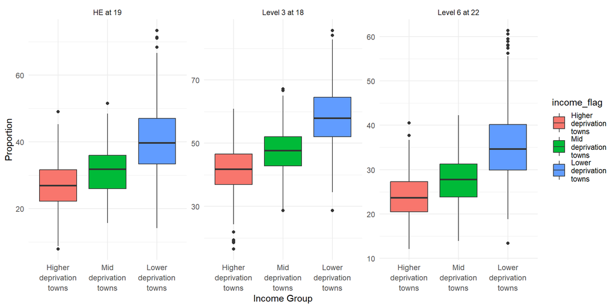

Figure 1: Educational Outcomes by Income Group(Cities Excluded)

**Clear trend**: Income linked to educational success

## Results

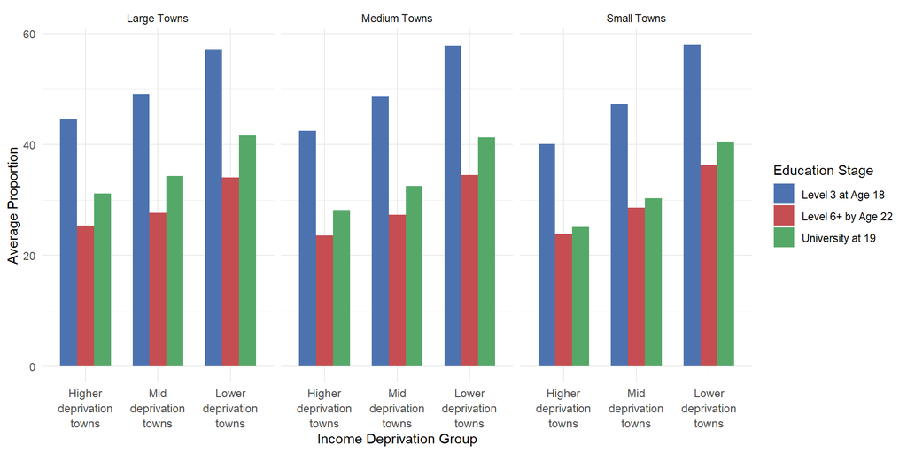

Figure 2: Educational Attainment by Income Deprivation Level and Town Size (Cities Excluded)

Educational attainment **rises** as income deprivation decreases.

**Lower deprivation towns outperform** others at ages 18, 19, and 22.

The gap is most pronounced in **small towns**, especially at Level 6+.

Highlights the role of local economic conditions.

## Conclusions and Recommendations

Strong link: **less deprived towns show better educational outcomes**.

Support should target **high-deprivation towns** — especially small ones.

Recommend **expanding dataset** and integrating qualitative factors.

## Ending Page

**Thank you!**

Presentation done!

Questions welcome.